# Final Project

Jules Pellin

2026-06-02

## Objective

This project analyzes the physical profiles of Olympic athletes across sports, sexes, and time using 120 years of Olympic history data (1896–2016). The central question is: how do height, weight, and BMI differ across sports, and how has the average age of Olympic athletes changed over time? As a former competitive handball player, I have a personal interest in understanding how athlete body types vary across different disciplines.

## Data

The dataset comes from Kaggle and contains two files: athlete_events.csv with 271,116 observations across 15 variables (name, sex, age, height, weight, sport, event, medal, year, country code), and noc_regions.csv which maps country codes to region names. Each row represents one athlete’s participation in one Olympic event, making it tidy by definition, every column is a variable, every row is an observation, and every cell contains a single value.

## Workflow

The script starts by loading and joining both files, then narrows things down to Summer Olympics only and drops athletes with missing height or weight data. A BMI column gets added from there, and the rest of the project builds off that cleaned dataset through four visualizations exploring how physical profiles vary across sports, sexes, and time.

```r
library(tidyverse)
library(ggridges)

# Load both files
athletes <- read.csv("athlete_events.csv")
noc      <- read.csv("noc_regions.csv")

head(athletes)
```

```
##   ID                     Name Sex Age Height Weight           Team NOC
## 1  1                A Dijiang   M  24    180     80          China CHN
## 2  2                 A Lamusi   M  23    170     60          China CHN
## 3  3      Gunnar Nielsen Aaby   M  24     NA     NA        Denmark DEN
## 4  4     Edgar Lindenau Aabye   M  34     NA     NA Denmark/Sweden DEN
## 5  5 Christine Jacoba Aaftink   F  21    185     82    Netherlands NED
## 6  5 Christine Jacoba Aaftink   F  21    185     82    Netherlands NED
##         Games Year Season      City         Sport
## 1 1992 Summer 1992 Summer Barcelona    Basketball
## 2 2012 Summer 2012 Summer    London          Judo
## 3 1920 Summer 1920 Summer Antwerpen      Football
## 4 1900 Summer 1900 Summer     Paris    Tug-Of-War
## 5 1988 Winter 1988 Winter   Calgary Speed Skating
## 6 1988 Winter 1988 Winter   Calgary Speed Skating
##                                Event Medal
## 1        Basketball Men's Basketball  <NA>
## 2       Judo Men's Extra-Lightweight  <NA>
## 3            Football Men's Football  <NA>
## 4        Tug-Of-War Men's Tug-Of-War  Gold
## 5   Speed Skating Women's 500 metres  <NA>
## 6 Speed Skating Women's 1,000 metres  <NA>
```

```r
str(athletes)
```

```
## 'data.frame':    271116 obs. of  15 variables:
##  $ ID    : int  1 2 3 4 5 5 5 5 5 5 ...
##  $ Name  : chr  "A Dijiang" "A Lamusi" "Gunnar Nielsen Aaby" "Edgar Lindenau Aabye" ...
##  $ Sex   : chr  "M" "M" "M" "M" ...
##  $ Age   : int  24 23 24 34 21 21 25 25 27 27 ...
##  $ Height: int  180 170 NA NA 185 185 185 185 185 185 ...
##  $ Weight: num  80 60 NA NA 82 82 82 82 82 82 ...
##  $ Team  : chr  "China" "China" "Denmark" "Denmark/Sweden" ...
##  $ NOC   : chr  "CHN" "CHN" "DEN" "DEN" ...
##  $ Games : chr  "1992 Summer" "2012 Summer" "1920 Summer" "1900 Summer" ...
##  $ Year  : int  1992 2012 1920 1900 1988 1988 1992 1992 1994 1994 ...
##  $ Season: chr  "Summer" "Summer" "Summer" "Summer" ...
##  $ City  : chr  "Barcelona" "London" "Antwerpen" "Paris" ...
##  $ Sport : chr  "Basketball" "Judo" "Football" "Tug-Of-War" ...
##  $ Event : chr  "Basketball Men's Basketball" "Judo Men's Extra-Lightweight" "Football Men's Football" "Tug-Of-War Men's Tug-Of-War" ...
##  $ Medal : chr  NA NA NA "Gold" ...
```

```r
# Join athlete data with region names by NOC code
dat <- merge(athletes, noc, by = "NOC", all.x = TRUE)

# Filter to Summer Olympics only
dat <- dat[dat$Season == "Summer", ]

# Remove rows where Height or Weight are NA (needed for physical analysis)
dat_clean <- dat[!is.na(dat$Height) & !is.na(dat$Weight), ]

# Calculate BMI
dat_clean$BMI <- dat_clean$Weight / ((dat_clean$Height / 100)^2)

# Report missing data handling
cat("Original rows:", nrow(athletes), "\n")
```

```
## Original rows: 271116
```

```r
cat("After Summer filter:", nrow(dat), "\n")
```

```
## After Summer filter: 222552
```

```r
cat("After removing NA Height/Weight:", nrow(dat_clean), "\n")
```

```
## After removing NA Height/Weight: 167361
```

```r
head(dat_clean[, c("Name", "Sport", "Height", "Weight", "BMI", "region")])
```

```
##                    Name     Sport Height Weight      BMI      region
## 3     Mohammad Halilula Wrestling    163     57 21.45357 Afghanistan
## 6  Sultan Mohammad Dost Wrestling    168     73 25.86451 Afghanistan
## 11 Nizam-ud-din Subhani Wrestling    168    111 39.32823 Afghanistan
## 13    Khojawahid Zahedi Wrestling    178     74 23.35564 Afghanistan
## 15   Abdul Hadi Shekaib Athletics    178     68 21.46194 Afghanistan
## 17   Habib Zareef Sayed Athletics    170     58 20.06920 Afghanistan
```

## Exploratory Analysis

### Visualization 1 - Height distribution by sport (Ridge Plot)

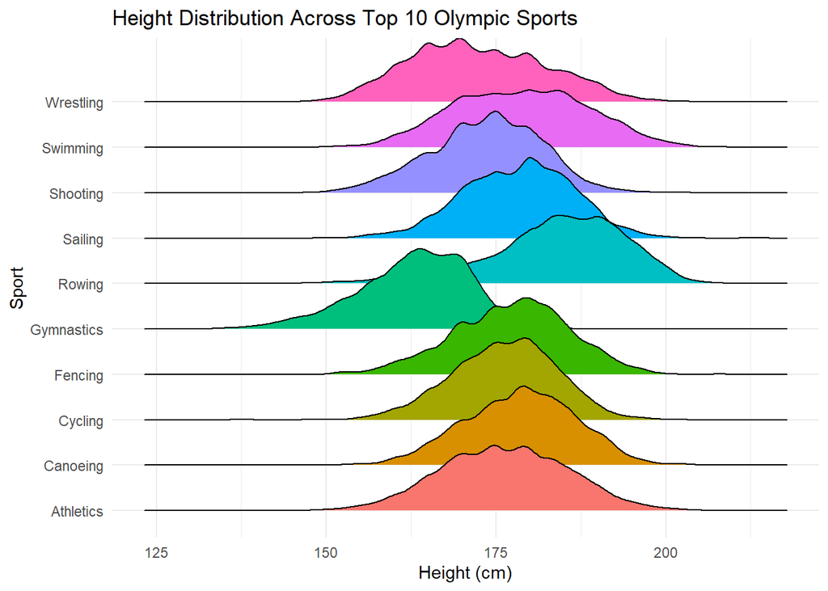

```r
# Select top 10 sports by athlete count for readability
top_sports <- dat_clean %>%
  count(Sport) %>%
  arrange(desc(n)) %>%
  slice_head(n = 10) %>%
  pull(Sport)

ridge_dat <- dat_clean[dat_clean$Sport %in% top_sports, ]

ggplot(ridge_dat, aes(x = Height, y = Sport, fill = Sport)) +
  geom_density_ridges() +
  labs(title = "Height Distribution Across Top 10 Olympic Sports",
       x = "Height (cm)",
       y = "Sport") +
  theme_minimal() +
  theme(legend.position = "none")
```

### Visualization 2 - Height vs Weight by Sex

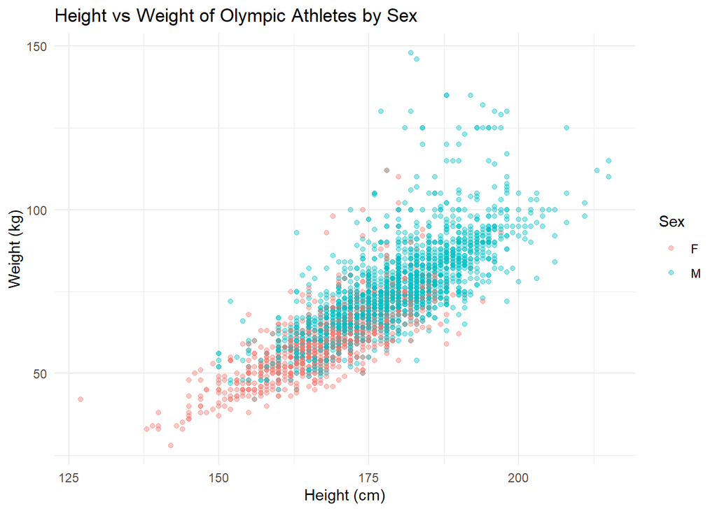

```r
# Sample 3000 rows for readability
set.seed(42)
sample_dat <- dat_clean[sample(nrow(dat_clean), 3000), ]

ggplot(sample_dat, aes(x = Height, y = Weight, color = Sex)) +
  geom_point(alpha = 0.4, size = 1.5) +
  labs(title = "Height vs Weight of Olympic Athletes by Sex",
       x = "Height (cm)",
       y = "Weight (kg)") +
  theme_minimal()
```

There’s a clear positive relationship between height and weight across all athletes. Male athletes are consistently taller and heavier, with their cluster sitting notably higher and to the right of the female cluster. Both sexes follow the same general linear trend though, taller athletes weigh more regardless of sex. The few extreme outliers at the top are likely weightlifters or shot putters where raw mass is an advantage.